# HR_Analytics

Adarsh Agrahari's HR Analytics EDA+PREDICTION

```python
import pandas as pd
import numpy as np
import matplotlib.pyplot as plt
import seaborn as sns
import scipy.stats as st
```

So basically it is a Classification Problem as we have to know if employee will be promoted or not

```python
train=pd.read_csv("train.csv")
```

```python
test=pd.read_csv("test.csv")
```

```python
train.shape
```

```
(54808, 14)
```

```python
test.shape
```

```
(23490, 13)
```

##### Problem Statement

Your client is a large MNC and they have 9 broad verticals across the organisation. One of the problem your client is facing is around identifying the right people for promotion (only for manager position and below) and prepare them in time. Currently the process, they are following is:

```
. They first identify a set of employees based on recommendations/ past performance

. Selected employees go through the separate training and evaluation program for each vertical. These programs are based on the required skill of each vertical

. At the end of the program, based on various factors such as training performance, KPI completion (only employees with KPIs completed greater than 60% are considered) etc., employee gets promotion

. For above mentioned process, the final promotions are only announced after the evaluation and this leads to delay in transition to their new roles. Hence, company needs your help in identifying the eligible candidates at a particular checkpoint so that they can expedite the entire promotion cycle.
```

They have provided multiple attributes around Employee's past and current performance along with demographics.

Now, The task is to predict whether a potential promotee at checkpoint in the test set will be promoted or not after the evaluation process.

```python
combined=pd.concat([train,test],ignore_index=True,sort=True)
```

```python
combined_backup=combined.copy()
```

```python
combined.head()
```

|  | KPIs_met >80% | age | avg_training_score | awards_won? | department | education | employee_id | gender | is_promoted | length_of_service | no_of_trainings | previous_year_rating | recruitment_channel | region |
| --- | --- | --- | --- | --- | --- | --- | --- | --- | --- | --- | --- | --- | --- | --- |
| 0 | 1 | 35 | 49 | 0 | Sales & Marketing | Master's & above | 65438 | f | 0.0 | 8 | 1 | 5.0 | sourcing | region_7 |
| 1 | 0 | 30 | 60 | 0 | Operations | Bachelor's | 65141 | m | 0.0 | 4 | 1 | 5.0 | other | region_22 |
| 2 | 0 | 34 | 50 | 0 | Sales & Marketing | Bachelor's | 7513 | m | 0.0 | 7 | 1 | 3.0 | sourcing | region_19 |
| 3 | 0 | 39 | 50 | 0 | Sales & Marketing | Bachelor's | 2542 | m | 0.0 | 10 | 2 | 1.0 | other | region_23 |
| 4 | 0 | 45 | 73 | 0 | Technology | Bachelor's | 48945 | m | 0.0 | 2 | 1 | 3.0 | other | region_26 |

```python
combined.info()
```

```
<class 'pandas.core.frame.DataFrame'>
RangeIndex: 78298 entries, 0 to 78297
Data columns (total 14 columns):
KPIs_met >80%           78298 non-null int64
age                     78298 non-null int64
avg_training_score      78298 non-null int64
awards_won?             78298 non-null int64
department              78298 non-null object
education               74855 non-null object
employee_id             78298 non-null int64
gender                  78298 non-null object
is_promoted             54808 non-null float64
length_of_service       78298 non-null int64
no_of_trainings         78298 non-null int64
previous_year_rating    72362 non-null float64
recruitment_channel     78298 non-null object
region                  78298 non-null object
dtypes: float64(2), int64(7), object(5)
memory usage: 8.4+ MB
```

```python
combined.isnull().sum()
```

```
KPIs_met >80%               0
age                         0
avg_training_score          0
awards_won?                 0
department                  0
education                3443
employee_id                 0
gender                      0
is_promoted             23490
length_of_service           0
no_of_trainings             0
previous_year_rating     5936
recruitment_channel         0
region                      0
dtype: int64
```

```python
combined.employee_id.nunique()
```

```
78298
```

```python
combined.shape
```

```
(78298, 14)
```

#### Age Analysis :

People with more than54 years of age are outliers

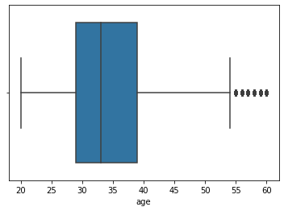

```python
sns.boxplot(combined.age)
```

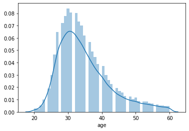

```python
sns.distplot(combined.age)
#Highly right skewed
```

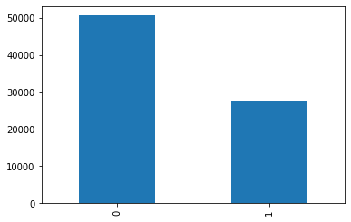

```python
combined["KPIs_met >80%"].value_counts().plot(kind="bar")
```

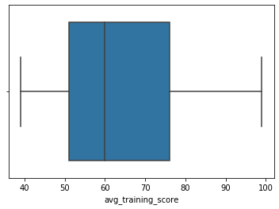

```python
sns.boxplot(combined["avg_training_score"])
```

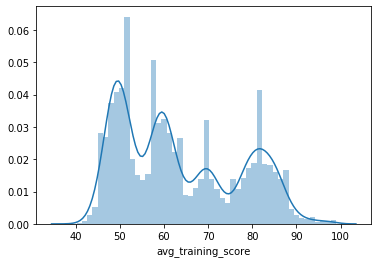

```python
sns.distplot(combined["avg_training_score"])
```

average training score is grouped we can clearly see it

```
most people lie on 45-50 bracket with higher intensity
a few people lie on 70 bracket
50,60,70,85
```

```python
combined.columns
```

```
Index(['KPIs_met >80%', 'age', 'avg_training_score', 'awards_won?',
       'department', 'education', 'employee_id', 'gender', 'is_promoted',
       'length_of_service', 'no_of_trainings', 'previous_year_rating',
       'recruitment_channel', 'region'],
      dtype='object')
```

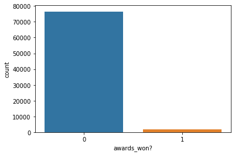

```python
sns.countplot(combined["awards_won?"])

#maximum poeple has won no awards. so obviously maximum people has got no awrds,

# we can figure out which are the poeple who got awards and were they promoted or
```

[figure not shown]

```python
combined[(combined["awards_won?"]==1) & (combined["is_promoted"]==1.0)]["age"]
```

```
     559 PEOPLE WHO GOT PROMOTED AND WON AWARDS
```

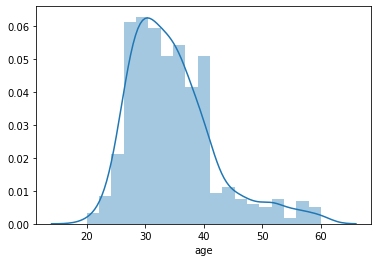

```python
sns.distplot(combined[(combined["awards_won?"]==1) & (combined["is_promoted"]==1.0)]["age"])
```

Most people who got promoted and won awards are of 30 years of age

```python
combined[(combined["awards_won?"]==1) & (combined["is_promoted"]==0.0)]
```

|  | KPIs_met >80% | age | avg_training_score | awards_won? | department | education | employee_id | gender | is_promoted | length_of_service | no_of_trainings | previous_year_rating | recruitment_channel | region |
| --- | --- | --- | --- | --- | --- | --- | --- | --- | --- | --- | --- | --- | --- | --- |
| 138 | 1 | 31 | 78 | 1 | Technology | Bachelor's | 51164 | f | 0.0 | 4 | 1 | 4.0 | other | region_14 |
| 140 | 1 | 30 | 76 | 1 | Technology | Bachelor's | 7606 | f | 0.0 | 7 | 2 | 3.0 | other | region_29 |
| 208 | 0 | 50 | 58 | 1 | Legal | Master's & above | 18981 | m | 0.0 | 6 | 1 | 5.0 | sourcing | region_2 |
| 239 | 1 | 38 | 60 | 1 | Operations | Bachelor's | 9563 | m | 0.0 | 7 | 2 | 3.0 | other | region_31 |
| 250 | 0 | 30 | 50 | 1 | Sales & Marketing | Bachelor's | 40376 | m | 0.0 | 4 | 1 | 5.0 | other | region_4 |
| ... | ... | ... | ... | ... | ... | ... | ... | ... | ... | ... | ... | ... | ... | ... |
| 54641 | 0 | 42 | 47 | 1 | Sales & Marketing | Bachelor's | 2467 | m | 0.0 | 4 | 1 | 2.0 | other | region_27 |
| 54702 | 0 | 28 | 62 | 1 | Operations | Bachelor's | 4952 | m | 0.0 | 2 | 1 | 3.0 | other | region_28 |
| 54772 | 1 | 37 | 57 | 1 | Operations | Master's & above | 34501 | m | 0.0 | 2 | 1 | 5.0 | other | region_27 |
| 54797 | 1 | 28 | 47 | 1 | Sales & Marketing | Bachelor's | 62450 | m | 0.0 | 3 | 1 | 5.0 | sourcing | region_11 |
| 54799 | 1 | 50 | 67 | 1 | Procurement | Master's & above | 68093 | f | 0.0 | 6 | 1 | 5.0 | other | region_2 |

711 rows × 14 columns

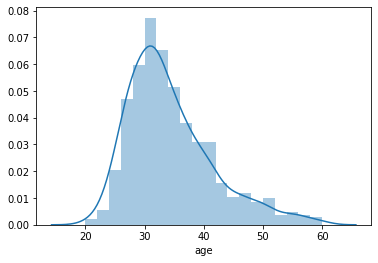

```python
sns.distplot(combined[(combined["awards_won?"]==1) & (combined["is_promoted"]==0.0)]["age"])
```

```python
combined[(combined["awards_won?"]==0) & (combined["is_promoted"]==1.0)]
```

|  | KPIs_met >80% | age | avg_training_score | awards_won? | department | education | employee_id | gender | is_promoted | length_of_service | no_of_trainings | previous_year_rating | recruitment_channel | region |
| --- | --- | --- | --- | --- | --- | --- | --- | --- | --- | --- | --- | --- | --- | --- |
| 11 | 1 | 35 | 50 | 0 | Sales & Marketing | Bachelor's | 49017 | f | 1.0 | 3 | 1 | 5.0 | sourcing | region_7 |
| 39 | 1 | 33 | 51 | 0 | Sales & Marketing | Bachelor's | 58304 | m | 1.0 | 6 | 1 | 5.0 | sourcing | region_28 |
| 60 | 1 | 50 | 47 | 0 | Sales & Marketing | Master's & above | 17673 | m | 1.0 | 17 | 1 | 4.0 | other | region_4 |
| 67 | 0 | 27 | 61 | 0 | Sales & Marketing | Bachelor's | 16502 | m | 1.0 | 1 | 1 | NaN | sourcing | region_22 |
| 69 | 1 | 30 | 84 | 0 | Analytics | Bachelor's | 45624 | m | 1.0 | 7 | 1 | 3.0 | other | region_31 |
| ... | ... | ... | ... | ... | ... | ... | ... | ... | ... | ... | ... | ... | ... | ... |
| 54734 | 1 | 31 | 56 | 0 | Operations | Bachelor's | 11685 | m | 1.0 | 1 | 1 | NaN | sourcing | region_15 |
| 54757 | 0 | 54 | 81 | 0 | Technology | Master's & above | 14502 | m | 1.0 | 7 | 1 | 4.0 | other | region_7 |
| 54761 | 1 | 30 | 86 | 0 | Procurement | Bachelor's | 8278 | f | 1.0 | 2 | 1 | 4.0 | sourcing | region_13 |
| 54792 | 0 | 59 | 65 | 0 | Sales & Marketing | Bachelor's | 994 | m | 1.0 | 11 | 1 | 3.0 | other | region_14 |
| 54796 | 0 | 34 | 60 | 0 | Sales & Marketing | Master's & above | 12592 | m | 1.0 | 7 | 1 | 3.0 | other | region_25 |

4109 rows × 14 columns

```python
#0 awards won and is getting promoted is 4109
```

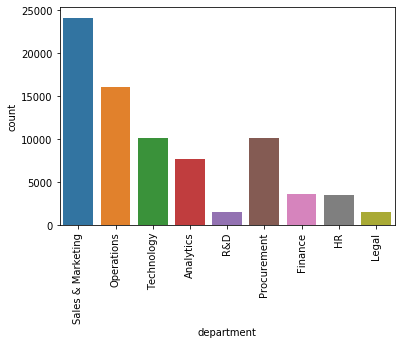

```python
sns.countplot(combined.department)
plt.xticks(rotation=90)
```

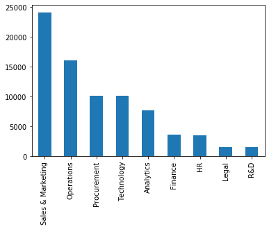

```python
combined.department.value_counts().plot(kind="bar")
```

Sales & Marketing

Operations

Procurement

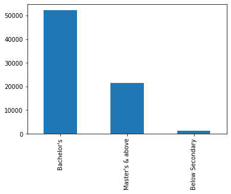

```python
combined.education.value_counts().plot(kind="bar")
```

```python
#most people are bachelors
```

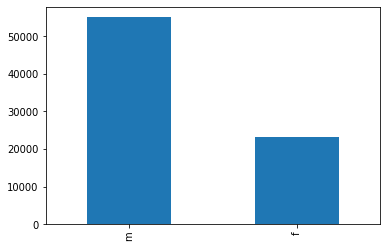

```python
combined.gender.value_counts().plot(kind="bar")
```

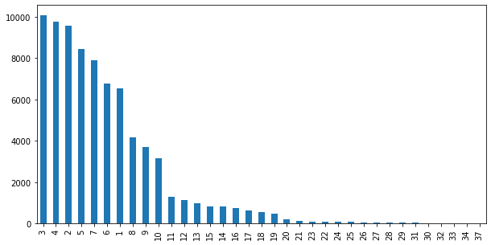

```python
plt.figure(figsize=(10,5))
combined.length_of_service.value_counts().plot(kind="bar")
plt.xticks(rotation=90)
```

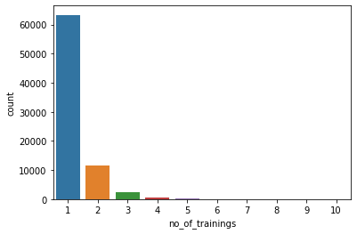

```python
sns.countplot(combined["no_of_trainings"])
```

#### most poeple have done 1 Year of training

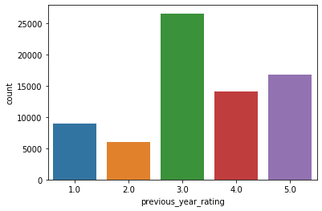

```python
sns.countplot(combined.previous_year_rating)
```

##### Maximum people with rating = 3

##### Minimum people with rating = 2.0

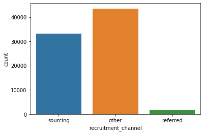

```python
sns.countplot(combined.recruitment_channel)
```

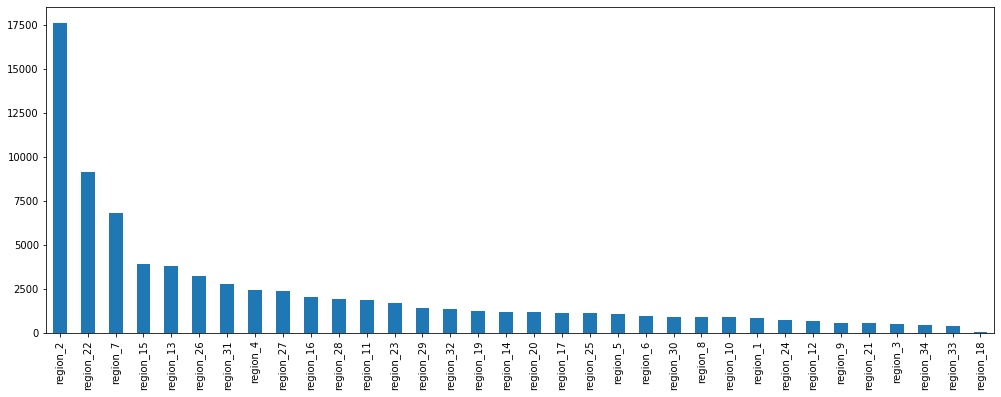

```python
combined.region.value_counts().plot(kind="bar",figsize=(17,6))
```

Maximum Region id is region 2

##### Bi-Variate Analysis

```python
combined.head()
```

|  | KPIs_met >80% | age | avg_training_score | awards_won? | department | education | employee_id | gender | is_promoted | length_of_service | no_of_trainings | previous_year_rating | recruitment_channel | region |
| --- | --- | --- | --- | --- | --- | --- | --- | --- | --- | --- | --- | --- | --- | --- |
| 0 | 1 | 35 | 49 | 0 | Sales & Marketing | Master's & above | 65438 | f | 0.0 | 8 | 1 | 5.0 | sourcing | region_7 |
| 1 | 0 | 30 | 60 | 0 | Operations | Bachelor's | 65141 | m | 0.0 | 4 | 1 | 5.0 | other | region_22 |
| 2 | 0 | 34 | 50 | 0 | Sales & Marketing | Bachelor's | 7513 | m | 0.0 | 7 | 1 | 3.0 | sourcing | region_19 |
| 3 | 0 | 39 | 50 | 0 | Sales & Marketing | Bachelor's | 2542 | m | 0.0 | 10 | 2 | 1.0 | other | region_23 |
| 4 | 0 | 45 | 73 | 0 | Technology | Bachelor's | 48945 | m | 0.0 | 2 | 1 | 3.0 | other | region_26 |

```python
#Going for Boxplots
```

[figure not shown]

```python
sns.boxplot(combined["awards_won?"],combined.age)
```

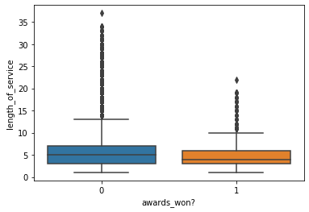

```python
sns.boxplot(combined["awards_won?"],combined.length_of_service)
```

[figure not shown]

```python
sns.boxplot(combined["awards_won?"],combined.no_of_trainings)
```

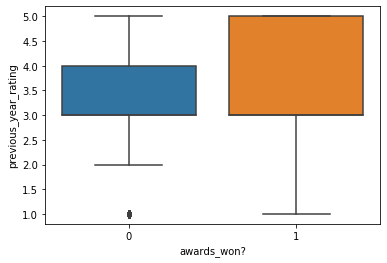

```python
sns.boxplot(combined["awards_won?"],combined.previous_year_rating)
```

maximum poeple who won awards have 3 to 5 previous year rating

[figure not shown]

```python
sns.boxplot(combined["awards_won?"],combined.recruitment_channel.value_counts())
```

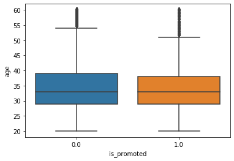

```python
sns.boxplot(combined["is_promoted"],combined.age)
```

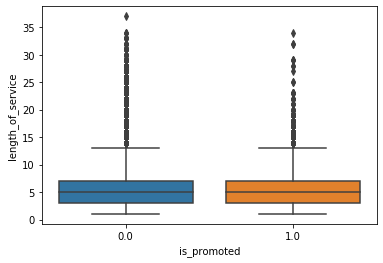

```python
sns.boxplot(combined["is_promoted"],combined.length_of_service)
```

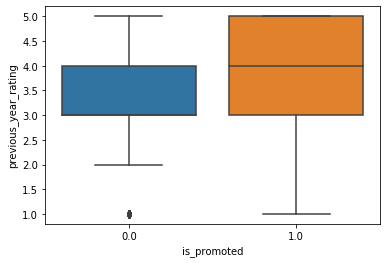

```python
sns.boxplot(combined["is_promoted"],combined.previous_year_rating)
```

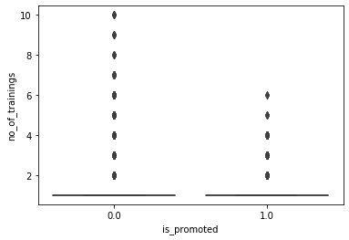

```python
sns.boxplot(combined["is_promoted"],combined.no_of_trainings)
```

```python
#Numerical vs Numerical
```

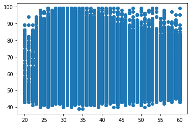

```python
plt.scatter(combined.age,combined.avg_training_score)
```

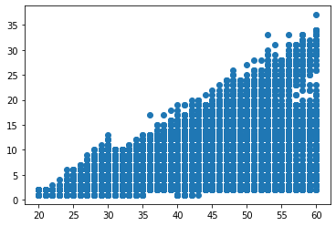

```python
plt.scatter(combined.age,combined.length_of_service)
# we can clearly see with age length of service is increasing
```

```python
#categorical vs categorical analysis
combined.head()
```

|  | KPIs_met >80% | age | avg_training_score | awards_won? | department | education | employee_id | gender | is_promoted | length_of_service | no_of_trainings | previous_year_rating | recruitment_channel | region |
| --- | --- | --- | --- | --- | --- | --- | --- | --- | --- | --- | --- | --- | --- | --- |
| 0 | 1 | 35 | 49 | 0 | Sales & Marketing | Master's & above | 65438 | f | 0.0 | 8 | 1 | 5.0 | sourcing | region_7 |
| 1 | 0 | 30 | 60 | 0 | Operations | Bachelor's | 65141 | m | 0.0 | 4 | 1 | 5.0 | other | region_22 |
| 2 | 0 | 34 | 50 | 0 | Sales & Marketing | Bachelor's | 7513 | m | 0.0 | 7 | 1 | 3.0 | sourcing | region_19 |
| 3 | 0 | 39 | 50 | 0 | Sales & Marketing | Bachelor's | 2542 | m | 0.0 | 10 | 2 | 1.0 | other | region_23 |
| 4 | 0 | 45 | 73 | 0 | Technology | Bachelor's | 48945 | m | 0.0 | 2 | 1 | 3.0 | other | region_26 |

[figure not shown]

```python
combined.groupby(["education","department"]).describe().plot(kind="bar",figsize=(20,10))
```